# NHC Patient Satisfaction Survey Results

Haleigh Schwartz

2024-12-26

# Background:

### Every 6 months, FTCA requires NHC to complete a patient satisfaction survey. Surveys ask 14 questions which all range from 1 (worst) to 4 (best). There is a section to leave additional comments.

### In December of 2024, we had 43 responses. Since collecting surveys in 2017, we have had a total of 411 responses.

### This page is a brief summary of the most pertinent results of both this most recent survey (12/2024) and collective results since 2017.

# Results:

### 1. We do a great job at being very attentive (Q11) and respectful (Q13) but not at explaining our wait times (Q4).

#### From the compiled survey responses (2017-2024, not shown), Question 4 was significantly lower than all other questions (p value < 0.001). **We could increase our standard visit to 45min to help with the wait times as this has been a recurrent complaint over the years.**

##### (Hover over the graph to see what the questions were)

[interactive chart not shown]

### 2. The results from this survey (12/2024) are about the same as our overall average from compiled results (2017-06/2024).

##### None of the differences were statistically significant, so the results we saw this time (12/2024) are in line with how we have been doing in the past.

##### (Hover over the graph to see what the questions were)

[interactive chart not shown]

### 3. Patients were overwhelmingly positive (over 90%)! Here are some of the most commonly used words in their comments.

##### (Color-coded and sized based on frequency)

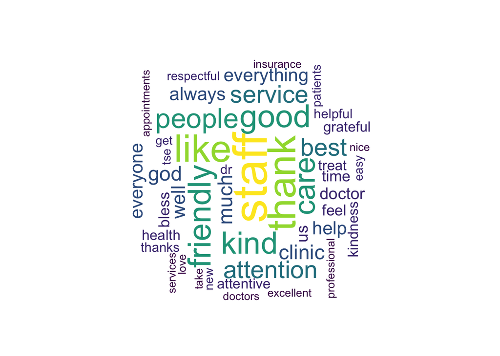

# Summary:

### We are doing so well! Patients feel very loved and cared for. The biggest area for improvement is the wait times. Making our appts longer will help with this, as we won’t get so backed up when we are running behind.

### However, this will reduce the number of total patients seen. This result, along with the findings from the previous analysis this year, further points to the need for more volunteer providers.

##### Let me know if you have any questions or want me to look at anything else! -Haleigh